# Tu primer modelo de machine learning

0.Opciones generales

```r
options(scipen=999)#Desactiva la notacion cientifica
```

1.Instalamos y cargamos las librerías necesarias

```r
#Instalar librerías
#install.packages('dplyr') #para manipular datos
#install.packages('skimr') #para exploración inicial
#install.packages('lubridate') #para manipular fechas
#install.packages('tidyr') #para manipular datos
#install.packages('ggplot2') #para hacer gráficos

#Cargar librerías
library(dplyr)
library(skimr)
library(lubridate)
library(tidyr)
library(ggplot2)
```

2.Cargamos los datos

```r
df = read.csv(file = "../project/DataSetFallosMaquina.csv", head = T, sep = ";")
```

3. Analisis Inicial

```r
glimpse(df) # Tipos de Datos de df
```

```
Rows: 8,784
Columns: 20
$ Temperature                  <int> 67, 68, 64, 63, 65, 67, 67, 67, 65, 63, 61,...
$ Humidity                     <int> 82, 77, 76, 80, 81, 84, 83, 76, 80, 80, 83,...
$ Operator                     <fct> Operator1, Operator1, Operator1, Operator1,...
$ Measure1                     <int> 291, 1180, 1406, 550, 1928, 398, 847, 1021,...
$ Measure2                     <int> 1, 1, 1, 1, 1, 1, 0, 2, 2, 0, 2, 3, 0, 1, 3...
$ Measure3                     <int> 1, 1, 1, 1, 2, 2, 2, 1, 0, 0, 2, 1, 0, 1, 0...
$ Measure4                     <int> 1041, 1915, 511, 1754, 1326, 1901, 1849, 18...
$ Measure5                     <int> 846, 1194, 1577, 1834, 1082, 1801, 1141, 17...
$ Measure6                     <int> 334, 637, 1121, 1413, 233, 1153, 1609, 952,...
$ Measure7                     <int> 706, 1093, 1948, 1151, 1441, 1085, 982, 118...
$ Measure8                     <int> 1086, 524, 1882, 945, 1736, 1547, 1159, 132...
$ Measure9                     <int> 256, 919, 1301, 1312, 1033, 2005, 672, 427,...
$ Measure10                    <int> 1295, 245, 273, 1494, 1549, 477, 1128, 1638...
$ Measure11                    <int> 766, 403, 1927, 1755, 802, 1217, 663, 850, ...
$ Measure12                    <int> 968, 723, 1123, 1434, 1819, 1632, 1114, 379...
$ Measure13                    <int> 1185, 1446, 717, 502, 1616, 1324, 1838, 152...
$ Measure14                    <int> 1355, 719, 1518, 1336, 1507, 1854, 290, 755...
$ Measure15                    <int> 1842, 748, 1689, 711, 507, 1739, 1192, 844,...
$ Hours.Since.Previous.Failure <int> 90, 91, 92, 93, 94, 95, 96, 97, 98, 99, 100...
$ Failure                      <fct> No, No, No, No, No, No, No, No, No, No, No,...
```

```r
skim(df) # Cuadro con todas las medidas estadisticas basicas
```

```
-- Data Summary ------------------------
                           Values
Name                       df
Number of rows             8784
Number of columns          20
_______________________
Column type frequency:
  factor                   2
  numeric                  18
________________________
Group variables            None

-- Variable type: factor ------------------------------------------------------------
# A tibble: 2 x 6
  skim_variable n_missing complete_rate ordered n_unique
* <chr>             <int>         <dbl> <lgl>      <int>
1 Operator              0             1 FALSE          8
2 Failure               0             1 FALSE          2
  top_counts
* <chr>
1 Ope: 1952, Ope: 976, Ope: 976, Ope: 976
2 No: 8703, Yes: 81

-- Variable type: numeric -----------------------------------------------------------
# A tibble: 18 x 11
   skim_variable                n_missing complete_rate     mean      sd    p0   p25
 * <chr>                            <int>         <dbl>    <dbl>   <dbl> <dbl> <dbl>
 1 Temperature                          0             1   64.0     2.87      5   62
 2 Humidity                             0             1   83.3     4.84     65   80
 3 Measure1                             0             1 1091.    537.      155  629
 4 Measure2                             0             1    1.49    1.12      0    0
 5 Measure3                             0             1    0.999   0.816     0    0
 6 Measure4                             0             1 1072.    537.      155  609.
 7 Measure5                             0             1 1076.    533.      155  606
 8 Measure6                             0             1 1076.    534.      155  623
 9 Measure7                             0             1 1087.    538.      155  621
10 Measure8                             0             1 1077.    537.      155  612
11 Measure9                             0             1 1082.    533.      155  631
12 Measure10                            0             1 1082.    538.      155  619
13 Measure11                            0             1 1089.    535.      155  627
```

[output cut: 10 more lines]

```
 4    1      2     3 ▇▇▁▇▇
 5    1      2     2 ▇▁▇▁▇
 6 1058   1533  2011 ▇▇▇▇▇
 7 1077   1541  2011 ▇▇▇▇▇
 8 1072   1537  2011 ▇▇▇▇▇
 9 1089   1558  2011 ▇▇▇▇▇
10 1074   1541  2011 ▇▇▇▇▇
11 1078   1532  2011 ▇▇▇▇▇
12 1080   1547  2011 ▇▇▇▇▇
13 1093   1550  2011 ▇▇▇▇▇
14 1082   1552  2011 ▇▇▇▇▇
15 1067   1539  2011 ▇▇▇▇▇
16 1088.  1560  2011 ▇▇▇▇▇
17 1076   1550  2011 ▇▇▇▇▇
18  195    324   666 ▇▆▅▂▁
```

Conclusiones: No hay nulos Problemas con tipos de variables: - Measure2 y Measure3 también parecen más factores que enteros - Viendo el mínimo y el p25 de Temperature parece que tiene atípicos

Analizamos en mayor detalle la tempertura

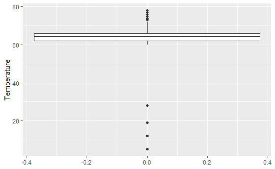

```r
ggplot(df,x=1) + geom_boxplot(aes(y=Temperature))
```

```r
#boxplot(df["Temperature"],main="Datos temperatura", ylab="Temperatura")
```

Conclusión: efectivamente vemos que son sólo 4 puntos

4.Calidad de datos

```r
#Corregimos los tipos de variables y los atípicos "%>%" une varios operaciones en una (concatena)
df <- df %>%
  mutate(Measure2 = as.factor(Measure2), #Corregimos Measure2
         Measure3 = as.factor(Measure3)) %>% #Corregimos Measure3
  filter(Temperature > 50) #eliminamos los 4 atípicos de temperature
```

5.Análisis exploratorio de variables (EDA)

```
attributes are not identical across measure variables;
they will be dropped
```

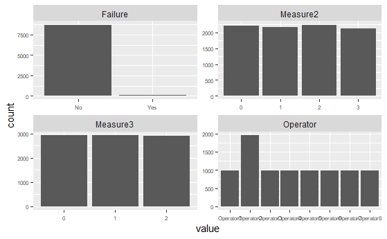

```r
#Exploramos las de tipo factor
df %>%
  select_if(is.factor) %>%
  gather() %>%
  ggplot(aes(value)) + geom_bar() + facet_wrap(~key,scales='free') +
  theme(axis.text=element_text(size=6))#esto es para cambiar el tamaño del texto del eje y que se lea bien
```

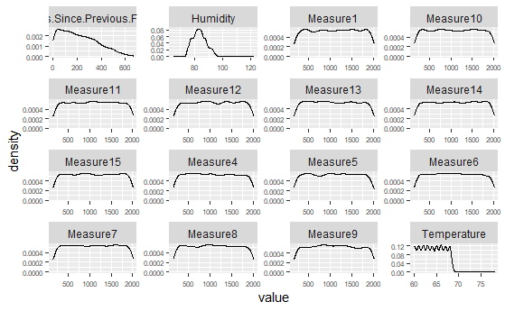

```r
#Y las de tipo entero
df %>%
  select_if(is.integer) %>%
  gather() %>%
  ggplot(aes(value)) + geom_density() + facet_wrap(~key,scales='free') +
  theme(axis.text=element_text(size=6))#esto es para cambiar el tamaño del texto del eje y que se lea bien
```

```r
#Hacemos análisis de correlaciones
df %>%
  select_if(is.integer) %>%
  cor() %>%
  round(digits = 2)
```

```
                             Temperature Humidity Measure1 Measure4 Measure5
Temperature                         1.00    -0.05     0.00    -0.02     0.01
Humidity                           -0.05     1.00     0.00     0.00    -0.03
Measure1                            0.00     0.00     1.00     0.00     0.01
Measure4                           -0.02     0.00     0.00     1.00     0.00
Measure5                            0.01    -0.03     0.01     0.00     1.00
Measure6                           -0.01    -0.01     0.01     0.02     0.00
Measure7                           -0.01    -0.02     0.00    -0.01     0.00
Measure8                            0.00     0.01     0.00     0.01    -0.01
Measure9                           -0.02     0.00    -0.01     0.01     0.00
Measure10                          -0.01     0.00     0.01     0.00    -0.01
Measure11                           0.01     0.03     0.00     0.01     0.01
Measure12                           0.00    -0.02    -0.01     0.02     0.01
Measure13                          -0.01    -0.02    -0.01    -0.02     0.01
Measure14                          -0.01     0.00     0.00    -0.01     0.02
Measure15                          -0.01    -0.02    -0.01     0.00     0.00
Hours.Since.Previous.Failure       -0.01     0.00     0.00    -0.02     0.00
                             Measure6 Measure7 Measure8 Measure9 Measure10 Measure11
Temperature                     -0.01    -0.01     0.00    -0.02     -0.01      0.01
Humidity                        -0.01    -0.02     0.01     0.00      0.00      0.03
Measure1                         0.01     0.00     0.00    -0.01      0.01      0.00
Measure4                         0.02    -0.01     0.01     0.01      0.00      0.01
Measure5                         0.00     0.00    -0.01     0.00     -0.01      0.01
Measure6                         1.00     0.00     0.00     0.01      0.01      0.00
Measure7                         0.00     1.00     0.00     0.00     -0.01      0.01
Measure8                         0.00     0.00     1.00     0.01     -0.02     -0.02
Measure9                         0.01     0.00     0.01     1.00      0.00      0.01
Measure10                        0.01    -0.01    -0.02     0.00      1.00      0.01
Measure11                        0.00     0.01    -0.02     0.01      0.01      1.00
Measure12                        0.02     0.00     0.00     0.02      0.01     -0.01
Measure13                       -0.01     0.00     0.00    -0.01      0.01      0.00
Measure14                       -0.01     0.01    -0.02     0.00      0.00      0.01
Measure15                       -0.01    -0.01     0.01     0.02     -0.02      0.01
Hours.Since.Previous.Failure    -0.01     0.00     0.01     0.00     -0.01      0.00
                             Measure12 Measure13 Measure14 Measure15
Temperature                       0.00     -0.01     -0.01     -0.01
Humidity                         -0.02     -0.02      0.00     -0.02
Measure1                         -0.01     -0.01      0.00     -0.01
Measure4                          0.02     -0.02     -0.01      0.00
Measure5                          0.01      0.01      0.02      0.00
```

[output cut: 13 more lines]

```
Humidity                                             0.00
Measure1                                             0.00
Measure4                                            -0.02
Measure5                                             0.00
Measure6                                            -0.01
Measure7                                             0.00
Measure8                                             0.01
Measure9                                             0.00
Measure10                                           -0.01
Measure11                                            0.00
Measure12                                           -0.02
Measure13                                            0.01
Measure14                                            0.00
Measure15                                           -0.01
Hours.Since.Previous.Failure                         1.00
```

```r
#Hacemos un zoom sobre el desbalanceo de la variable target
table(df$Failure)
```

```
  No  Yes
8699   81
```

Conclusiones: No se perciben patrones raros en las variables Las variables de medidas no correlacionan La variable target está muy desbalanceada

6.Transformación de variables No son necesarias grandes transformaciones porque el fichero ya viene muy limpio (no pasa así en la realidad)

Tampoco vamos a crear variables sintéticas (nuevas variables) que sí haríamos en la realidad (por ej número de fallos del mismo equipo, etc.)

Pero sí vamos a tener que trabajar sobre el balanceo de la variable target

```r
#Vamos a balancear usando la técnica del inframuestreo:
#Comprobamos la penetración exacta de la target
#Tenemos 81 sis que sobre el total de casos son un 0,9%:
81/nrow(df) * 100
```

```
[1] 0.9225513
```

```r
#Para tener casi un 10% necesitaríamos incrementar la proporción aprox en x10
#Entonces vamos a reducir los nos para que salga aprox esa proporción
#Nuevo df de nos
set.seed(1234) #para que nos salga lo mismo
df_nos <- df %>%
  filter(Failure == 'No') %>%
  sample_frac(size = 0.08)
#Df de sis
df_sis <- df %>% filter(Failure == 'Yes')
#Y los unimos de nuevo en un nuevo df reducido
df_red <- rbind(df_nos,df_sis)
#Comprobamos de nuevo la penetación de la target
count(df_red,Failure)
```

| Failure | n |
| --- | --- |
| No | 696 |
| Yes | 81 |

```r
81/nrow(df_red) * 100
```

```
[1] 10.42471
```

Ahora ya tenmos un dataset donde la target tiene un 10% de penetración (que sigue siendo poco pero lo dejaremos así)

7.Modelización

7.1 Dividir en entrentamiento y validación: No lo vamos a hacer por simplicidad y porque tenemos pocos casos

7.2 Roles de las variables

Vamos a modelizar con una regresión logística

```r
summary(rl) #Vemos el resultado
```

[output not shown]

```
Call:
glm(formula = formula, family = binomial(link = "logit"), data = df_red)

Deviance Residuals:
    Min       1Q   Median       3Q      Max
-1.5992  -0.2251  -0.0829  -0.0319   3.9472

Coefficients:
                                 Estimate   Std. Error z value      Pr(>|z|)
(Intercept)                  -10.71197421   7.57929507  -1.413        0.1576
Temperature                    0.51063561   0.08439998   6.050 0.00000000145 ***
Humidity                      -0.32864864   0.05593164  -5.876 0.00000000421 ***
OperatorOperator2             -1.52872547   0.74583258  -2.050        0.0404 *
OperatorOperator3             -0.94127935   0.78199528  -1.204        0.2287
OperatorOperator4             -1.53555593   0.79710060  -1.926        0.0541 .
OperatorOperator5             -1.42656277   0.95686891  -1.491        0.1360
OperatorOperator6             -2.01372722   0.87352228  -2.305        0.0212 *
OperatorOperator7             -0.05600171   0.82303039  -0.068        0.9458
OperatorOperator8             -1.31565504   1.00509099  -1.309        0.1905
Measure1                      -0.00036411   0.00040945  -0.889        0.3739
Measure21                     -1.53274137   0.63978822  -2.396        0.0166 *
Measure22                     -0.88252115   0.59137875  -1.492        0.1356
Measure23                     -0.48864109   0.57668512  -0.847        0.3968
Measure31                      0.07341648   0.51626055   0.142        0.8869
Measure32                      0.40173345   0.52981346   0.758        0.4483
Measure4                      -0.00012266   0.00037570  -0.326        0.7441
Measure5                       0.00062969   0.00039368   1.599        0.1097
Measure6                       0.00008513   0.00038514   0.221        0.8251
Measure7                       0.00013942   0.00039815   0.350        0.7262
Measure8                       0.00072147   0.00041811   1.726        0.0844 .
Measure9                      -0.00022261   0.00040967  -0.543        0.5869
Measure10                      0.00102269   0.00042532   2.405        0.0162 *
Measure11                     -0.00032465   0.00039685  -0.818        0.4133
Measure12                      0.00002618   0.00042355   0.062        0.9507
Measure13                      0.00023410   0.00040261   0.581        0.5609
Measure14                      0.00026506   0.00039471   0.672        0.5019
Measure15                      0.00017387   0.00040795   0.426        0.6700
Hours.Since.Previous.Failure  -0.00141645   0.00138640  -1.022        0.3069
---
Signif. codes:  0 ‘***’ 0.001 ‘**’ 0.01 ‘*’ 0.05 ‘.’ 0.1 ‘ ’ 1

(Dispersion parameter for binomial family taken to be 1)

    Null deviance: 519.53  on 776  degrees of freedom
Residual deviance: 187.39  on 748  degrees of freedom
AIC: 245.39

Number of Fisher Scoring iterations: 8
```

```r
indep_fin <- c('Temperature','Humidity','Operator','Measure2','Measure10')
formula <- reformulate(indep_fin,target) #actualizamos la fórmula
```

Y volvemos a modelizar

```r
rl <- glm(formula,df_red,family=binomial(link='logit'))
summary(rl) #Vemos el resultado
```

```
Call:
glm(formula = formula, family = binomial(link = "logit"), data = df_red)

Deviance Residuals:
    Min       1Q   Median       3Q      Max
-1.5168  -0.2410  -0.1041  -0.0374   3.4951

Coefficients:
                     Estimate  Std. Error z value       Pr(>|z|)
(Intercept)       -10.2423384   7.5669927  -1.354        0.17588
Temperature         0.5032308   0.0845514   5.952 0.000000002652
Humidity           -0.3164538   0.0506878  -6.243 0.000000000429
OperatorOperator2  -1.3007335   0.7052471  -1.844        0.06513
OperatorOperator3  -0.7903970   0.7451677  -1.061        0.28883
OperatorOperator4  -1.2402477   0.7563843  -1.640        0.10107
OperatorOperator5  -1.0614808   0.9178626  -1.156        0.24749
OperatorOperator6  -1.7633211   0.7996644  -2.205        0.02745
OperatorOperator7   0.1040170   0.7835992   0.133        0.89440
OperatorOperator8  -1.1864290   0.9426076  -1.259        0.20815
Measure21          -1.2625714   0.5783389  -2.183        0.02903
Measure22          -0.8359697   0.5589033  -1.496        0.13472
Measure23          -0.3245775   0.5450037  -0.596        0.55148
Measure10           0.0010738   0.0003951   2.718        0.00658

(Intercept)
Temperature       ***
Humidity          ***
OperatorOperator2 .
OperatorOperator3
OperatorOperator4
OperatorOperator5
OperatorOperator6 *
OperatorOperator7
OperatorOperator8
Measure21         *
Measure22
Measure23
Measure10         **
---
Signif. codes:  0 ‘***’ 0.001 ‘**’ 0.01 ‘*’ 0.05 ‘.’ 0.1 ‘ ’ 1

(Dispersion parameter for binomial family taken to be 1)

    Null deviance: 519.53  on 776  degrees of freedom
Residual deviance: 198.02  on 763  degrees of freedom
AIC: 226.02

Number of Fisher Scoring iterations: 7
```

Aplicamos nuestro modelo a los datos

```r
df$scoring <- predict(rl,df,type='response')
```

Tomamos la decisión de si pensamos que será un fallo o no

```r
#Como la penetración inicial era del 1%, vamos a poner un punto de corte muy alto, por ejemplo por encima del 80%
df$prediccion <- ifelse(df$scoring > 0.8,1,0)
```

8. Evaluación del modelo Vamos a contrastar la predicción contra la realidad

```r
table(df$prediccion,df$Failure)
```

```
      No  Yes
  0 8692   33
  1    7   48
```

De todos los que predigo que van a fallar la mayoría fallan, pero también me estoy dejando muchos fallos en el tintero por ser tan conservador

Y si fueramos menos exigentes y pusiéramos el corte un poco más abajo?

Tomamos la decisión de si pensamos que será un fallo o no

```r
#Vamos a ver qué pasa si bajamos la decisión al 60%
df$prediccion <- ifelse(df$scoring > 0.6,1,0)
```

Vamos a contrastar la predicción contra la realidad

```r
table(df$prediccion,df$Failure)
```

```
      No  Yes
  0 8657   26
  1   42   55
```